# Setup environment

[figure not shown]

In this exercise we will estimate ancestry proportions from a subset of human 1000 Genomes data. The data set has already been converted to PLINK format and subset to 12 individuals from each of 16 populations. Several populations are expected to be admixed.

```
# shared tools and data folder
ROOT_PATH=/course/chinacourse2026/shared
TOOL_PATH=${ROOT_PATH}/Software # for standalone tool script including java package
SHARED_PATH=${ROOT_PATH}/ref # For reference database
INPUT_PATH=${ROOT_PATH}/data/admixture_notebook_files  # for input data
INPUT_DATA_DIR=${INPUT_PATH}/input
PRECOMPUTE_DATA_DIR=${INPUT_PATH}/precomputed

mkdir -p ~/sysu2026_day4_pca
cd ~/sysu2026_day4_pca
echo "the working folder is " - `pwd`
cp -sf ${SHARED_PATH}/pcaone_*.json .
cp -sf ${SHARED_PATH}/pca_quiz*.json .
cp -sf ${SHARED_PATH}/visFuns.R .
cp -sf ${SHARED_PATH}/newPlotPlink.R .
cp -sf ${SHARED_PATH}/locuszoom_ref/refGeneHG38.gz .
ln -sf ${SHARED_PATH}/locuszoom_ref/hg38 .
```

```
the working folder is  - /home/albrecht/sysu2026_day4_pca
```

```
# set up R working space
work_d <- path.expand("~/sysu2026_day4_pca")
setwd(work_d)

geneticMap <- path.expand("~/sysu2026_day4_pca/hg38/genetic_map_GRCh38_chr")
refGenes <- path.expand("~/sysu2026_day4_pca/refGeneHG38.gz")

source("./visFuns.R")
source("./newPlotPlink.R")
```

```
# set up python working space
import os
work_d = os.path.expanduser("~/sysu2026_day4_pca")
os.chdir(work_d)
```

# PCA for genotype data using PCAone

In this exercise we will try to use PCAone to analyse the same data used in the ADMIXTURE exercises.

Genotypes were called for variable sites with high depth sequencing data from the 1000 genomes project

```
# Make new folder and set path to that folder
#make folder
#rm -rf pca
mkdir -p ~/sysu2026_day4_pca/pca


cp -sf ${PRECOMPUTE_DATA_DIR}/best_seed/human_autosomes_12pp_pcaoneLD02.4.best_seed5.Q ./pca/


##make links to files and add them to the folder
# links to LD-pruned genotype file from admixture analysis
cp -sf ${INPUT_DATA_DIR}/human_autosomes_12pp_pcaoneLD02* ./pca/


echo -e "\n--- files in folder ---"
ls ./pca


echo -e "\n--programs that are installed:--"
which PCAone
```

```
--- files in folder ---
eu1000g.sample.Info
eu1000g.small.beagle.gz
EUsmall.cov
EUsmall.log
EUsmall.selection
EUsmall.sites
EUsmall.sites.info
human_autosomes_12pp_pcaoneLD02.4.best_seed5.Q
human_autosomes_12pp_pcaoneLD02.bed
human_autosomes_12pp_pcaoneLD02.bim
human_autosomes_12pp_pcaoneLD02.fam
human_autosomes_12pp_pcaoneLD02.labels.tsv
PCAONE_K10.eigvals
PCAONE_K10.eigvecs
PCAONE_K10.eigvecs2
PCAONE_K10.log
PCAONE_K10.sigvals

--programs that are installed:--
/usr/local/bin/PCAone
```

Look inside the first lines in the population informaiton file.

```
echo --- first 10 lines of the popluation information ---

head ./pca/human_autosomes_12pp_pcaoneLD02.labels.tsv

echo --- summaries the second column ---
cut -d' ' -f2 ./pca/human_autosomes_12pp_pcaoneLD02.labels.tsv | sort |  uniq -c

echo --- summaries the third column ---
cut -d' ' -f3 ./pca/human_autosomes_12pp_pcaoneLD02.labels.tsv | sort |  uniq -c
```

```
--- first 10 lines of the popluation information ---
HG00096 GBR EUR
HG00097 GBR EUR
HG00099 GBR EUR
HG00100 GBR EUR
HG00101 GBR EUR
HG00102 GBR EUR
HG00103 GBR EUR
HG00105 GBR EUR
HG00106 GBR EUR
HG00107 GBR EUR
--- summaries the second column ---
     12 ACB
     12 ASW
     12 CEU
     12 CHB
     12 CHS
     12 CLM
     12 ESN
     12 GBR
     12 GWD
     12 IBS
     12 JPT
     12 MSL
     12 MXL
     12 PEL
     12 TSI
     12 YRI
--- summaries the third column ---
     72 AFR
     36 AMR
     36 EAS
     48 EUR
```

```
from jupyterquiz import display_quiz
display_quiz('pcaone_quiz1.json')
```

## Run PCAone to perform PCA

First let's get a list of the options in PCAone

```
${TOOL_PATH}/PCAone
```

```
PCA All In One (v0.7.2)        https://github.com/Zilong-Li/PCAone
(C) 2021-2024 Zilong Li        GNU General Public License v3

Usage: 1) use PLINK files as input and apply default window-based RSVD method
       $ PCAone -b plink

       2) use CSV file as input and apply the Implicitly Restarted Arnoldi Method
       $ PCAone -c csv.zst -d 0

       3) compute ancestry adjusted LD matrix and R2
       $ PCAone -b plink -k 2 -D -o adj
       $ PCAone -B adj.residuals -f adj.mbim -R --ld-bp 1000


General options:
  -h, --help                     print all options including hidden advanced options
  -m, --memory arg (=0)          RAM usage in GB unit for out-of-core mode. default is in-core mode
  -n, --threads arg (=12)        the number of threads to be used
  -v, --verbose arg (=1)         verbosity level for logs. Options are
                                 0: silent, no messages on screen;
                                 1: concise messages to screen;
                                 2: more verbose information;
                                 3: enable debug information.

PCA algorithms:
  -d, --svd arg (=2)             SVD method to be applied. default 2 is recommended for big data. Options are
                                 0: the Implicitly Restarted Arnoldi Method (IRAM);
                                 1: the Yu's single-pass Randomized SVD with power iterations;
                                 2: the accurate window-based Randomized SVD method (PCAone);
                                 3: the full Singular Value Decomposition.
  -k, --pc arg (=10)             top k principal components (PCs) to be calculated
  -C, --scale arg (=-9)          do normalization or scaling for input file. Options are
                                 -9: standardize genetic data by sqrt(ploidy*f*(1-f));
                                  0: do nothing and proceed to SVD;
                                  1: do direct standardization, as the scale(x, center=TRUE, scale=TRUE) function in R;
                                  2: do first count per median log transformation (CPMED), then standardization;
                                  3: do first log1p transformation, then standardization;
                                  4: do first relative counts, then standardization.
  --maxp arg (=20)               maximum number of power iterations for RSVD algorithm.
  -S, --no-shuffle               do not shuffle columns of data for --svd 2 (if not locally correlated).
```

[output cut: 33 more lines]

```
  --selection arg (=0)           compute selection statistics. Options are
                                 0: disabled;
                                 1: perform selection scan using Galinsky et al method;
                                 2: perform selection scan using PCAdapt method.
  --ld-r2 arg (=0)               R2 cutoff for LD-based pruning (usually 0.2).
  --ld-bp arg (=1000000)         physical distance threshold in bases for LD window.
  --ld-stats arg (=0)            statistics to compute LD R2 for pairwise SNPs. Options are
                                 0: the ancestry adjusted, i.e. correlation between residuals;
                                 1: the standard, i.e. correlation between two alleles.
  --clump arg                    assoc-like file with target variants and pvalues for clumping.
  --clump-names arg (=CHR,BP,P)  column names in assoc-like file for locating chr, pos and pvalue.
  --clump-p1 arg (=0.0001)       significance threshold for index SNPs.
  --clump-p2 arg (=0.01)         secondary significance threshold for clumped SNPs.
  --clump-r2 arg (=0.5)          r2 cutoff for LD-based clumping.
  --clump-bp arg (=250000)       physical distance threshold in bases for clumping.
```

PCAone is a fast and scalable tool for PCA analysis.

For this small dataset, it will be done in **~5 seconds**

```
${TOOL_PATH}/PCAone -b ./pca/human_autosomes_12pp_pcaoneLD02 -k 10 -d 0 -o ./pca/PCAONE_K10 -n 6
```

```
Machine name: x86_64
Node name: emily
Operating system release: 6.8.0-110-generic
Operating system version: #110~22.04.1-Ubuntu SMP PREEMPT_DYNAMIC Fri Mar 27 12:43:08 UTC
Operating system name: Linux
 PCAone (v0.7.2)    https://github.com/Zilong-Li/PCAone
Options in effect:
/course/chinacourse2026/shared/Software/PCAone -b ./pca/human_autosomes_12pp_pcaoneLD02 -k 10 -d 0 -o ./pca/PCAONE_K10 -n 6
[09/09/2026-09:16:09] program started
[09/09/2026-09:16:09] start parsing PLINK format
[09/09/2026-09:16:09] N (# samples): 192, M (# SNPs): 317850
[09/09/2026-09:16:09] done reading all data
[09/09/2026-09:16:09] running IRAM SVD with in-core mode.
[09/09/2026-09:16:13] eigen vectors and values saved
[09/09/2026-09:16:13] PCAone - IRAM SVD done
[09/09/2026-09:16:13] total elapsed reading time:  0.401000 seconds
[09/09/2026-09:16:13] total elapsed wall time: 4.198000 seconds
[09/09/2026-09:16:13] have a nice day. bye!
```

Let's look at the output of PCAone. Can you figure out what's stored in these output files?

```
ls pca/PCAONE_K10.*
```

```
pca/PCAONE_K10.eigvals  pca/PCAONE_K10.eigvecs2  pca/PCAONE_K10.sigvals
pca/PCAONE_K10.eigvecs  pca/PCAONE_K10.log
```

```
from jupyterquiz import display_quiz
display_quiz('pcaone_quiz2.json')
```

Now let's make PCA plots!

```
# Read eigenvector matrix calculated by PCAone
e <- read.table("./pca/PCAONE_K10.eigvecs")
# Read population and super-population labels for each individuals
labels<-read.table("./pca/human_autosomes_12pp_pcaoneLD02.labels.tsv",stringsAsFactors=T,head=F)
# use pch for different pop, use color for super-pops
pchs <- 1:20
plot(e[,1:2], pch=as.integer(factor(labels[,2])), col=factor(labels[,3]), xlab="PC1", ylab="PC2", cex=2)
legend("topleft",fill=1:4,levels(labels[,3]))
legend("top",legend=levels(labels[,2]),pch=pchs[seq_along(levels(labels[,2]))],col="black",bty="n",cex=1.2)
```

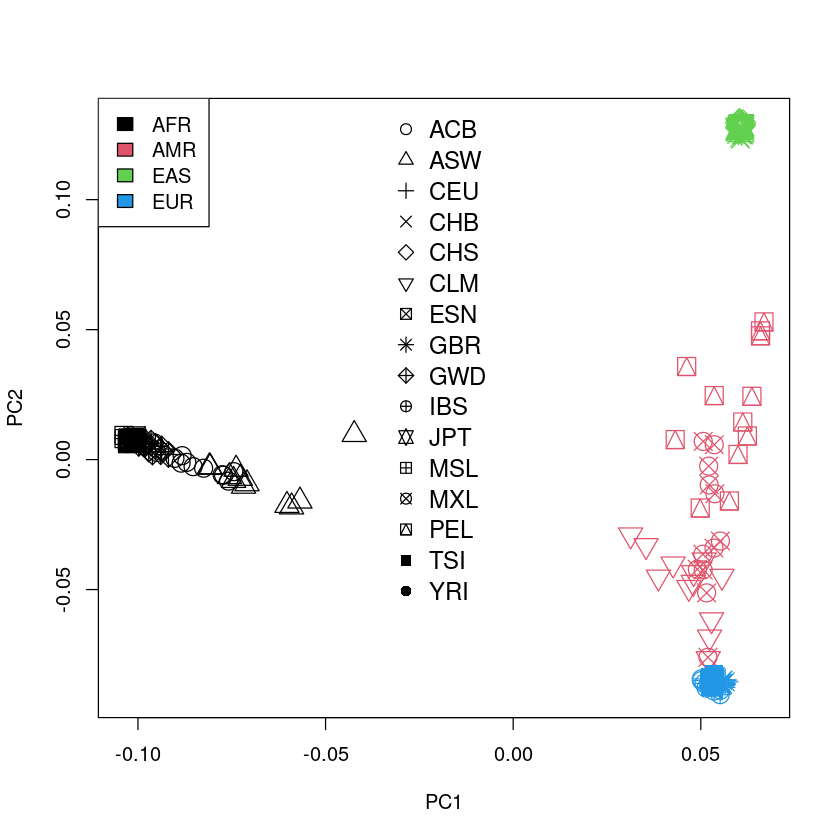

Compare with the estimate admixture proportions from ADMIXTURE analysis this morning

```
#read in code to plot admixture proportions ( plotAdmix function)
#source("https://raw.githubusercontent.com/GenisGE/evalAdmix/master/visFuns.R")

options(repr.plot.width=12, repr.plot.height=12)
layout(matrix(c(1,1,2,3),nrow=2,by=T),height=c(2,4),width=2:1)
# Read population and super-population labels for each individuals
labels<-read.table("./pca/human_autosomes_12pp_pcaoneLD02.labels.tsv",stringsAsFactors=T,head=F)
pop <- labels[,2]
pop_order <- c("GWD", "MSL", "YRI", "ESN", "ACB", "ASW",
               "GBR", "CEU", "IBS", "TSI",
               "CHB", "CHS", "JPT",
               "MXL", "CLM", "PEL")
ord <- unlist(lapply(pop_order, function(p) which(pop == p)))

admix_cols <- c(AMR="#FF7F00", AFR="#4DAF4A", EUR="#377EB8", EAS="#984EA3")

reorder_components <- function(q) {
  ref <- c("PEL", "YRI", "GBR", "CHB")
  kord <- sapply(ref, function(p) which.max(colMeans(q[pop == p,,drop=FALSE])))
  if(length(unique(kord)) == ncol(q)) q[,kord] else q
}

plot_geo_admix <- function(q, title) {
  plotAdmix(q, pop=pop, ord=ord, rotatelab=45, padj=0.12,
            cex.lab=1.0, cex.main=1.3, main=title,
            colorpal=unname(admix_cols[c("AMR", "AFR", "EUR", "EAS")]))
}

# Read in inferred admixture proportions
q_best <- read.table("./pca/human_autosomes_12pp_pcaoneLD02.4.best_seed5.Q")
q_best <- reorder_components(as.matrix(q_best))
plot_geo_admix(q_best, "ADMIXTURE proportions, K = 4, best seed = 5")
# Read eigenvector matrix calculated by PCAone
e <- read.table("./pca/PCAONE_K10.eigvecs")

pchs <- 1:20
# use pch for different pop, use color for super-pops
plot(e[,1:2], pch=pchs[factor(labels[,2])], col=factor(labels[,3]), xlab="PC1", ylab="PC2", cex=2)
legend("topleft",fill=1:4,levels(labels[,3]))
plot.new()
par(mar=c(0,0,0,0))
legend("top",legend=levels(labels[,2]),pch=pchs[seq_along(levels(labels[,2]))],col="black",bty="n",cex=1.5)
```

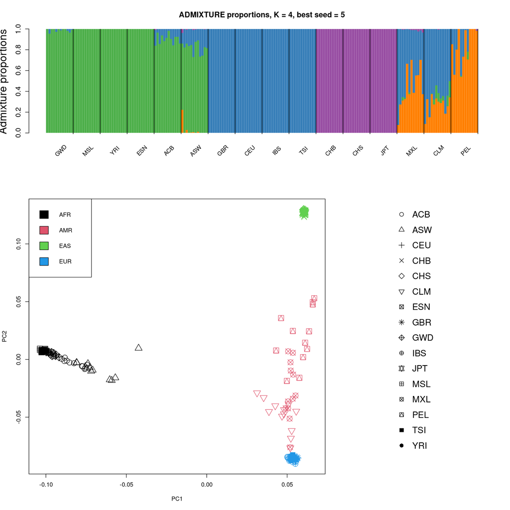

**Questions**

- What information do you get from the PCA that you don't get from the ADMIXTURE results?
- Can you identify the admixed individuals?

Lets see what the other PCs show.

```
par(mfrow=c(3,2))
for(pc in 1:5)
  plot(e[,1:2+2*(pc-1)], pch=pchs[as.integer(factor(labels[,2]))], col=factor(labels[,3]), ylab=paste("PC",pc*2),xlab=paste("PC",pc*2-1), cex=2);
```

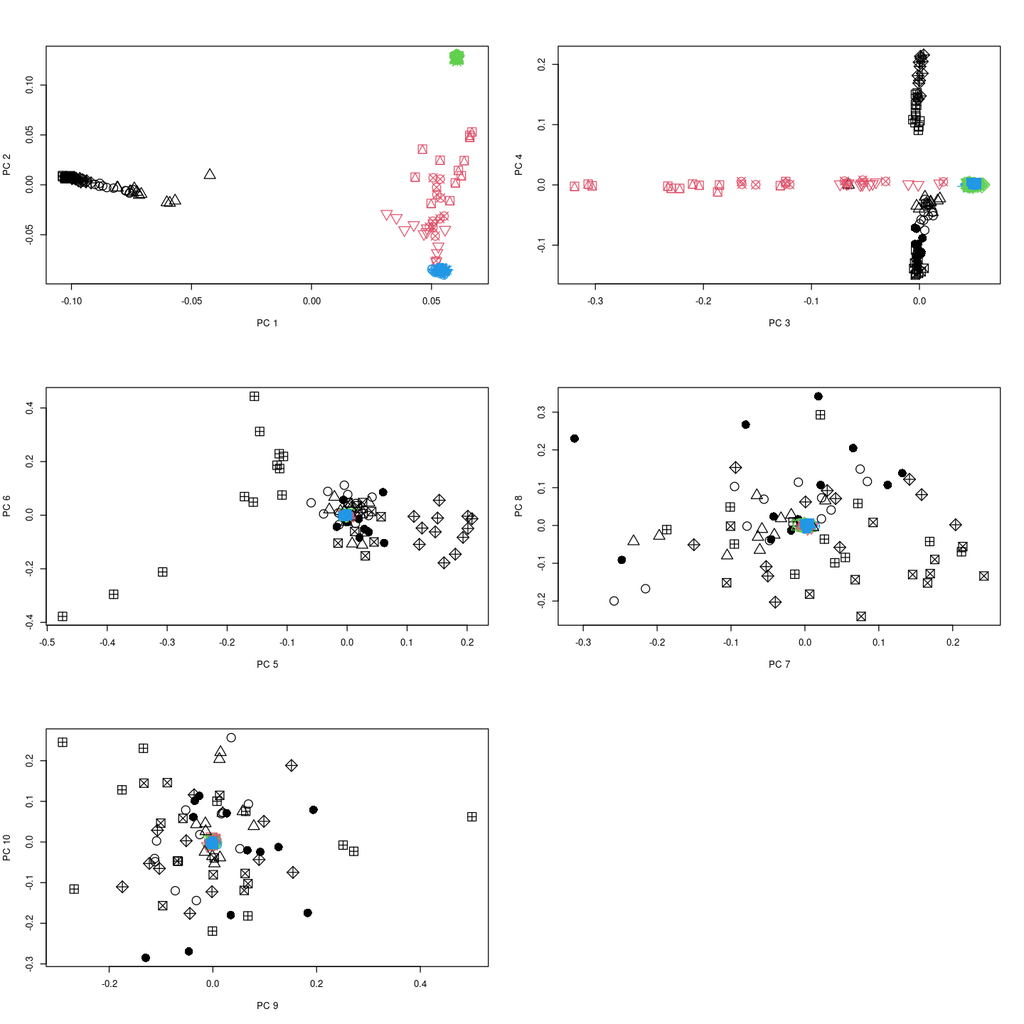

**Questions**

- How many PCs are used to separate the populations?
- What do you think is captured on PC 5 and 6?
- What do you think is captures on PC 9 and 10?

# PC-based selection

For very recent selection we can look within closely related individuals for example with in Europeans

**Data:**

- Genotype likelihoods in Beagle format
- ~150k random SNPs with maf > 5%
- Four EU populations with ~100 individuals in each
- whole genome sequencing
- depth 2-9X (1000 genome project)

```
CEU | Europeans in Utah (British)
GBR | Great Britain
IBS | Iberian/Spain
TSI | Italien
```

First let's set the paths

```
##make links to files and add them to the folder
# links to genotype likelihood file ( from admixture analysis )
cp -sf ${ROOT_PATH}/data/pca/eu1000g.small.beagle.gz ./pca/

# link to population information file
cp -sf ${ROOT_PATH}/data/pca/eu1000g.sample.Info ./pca/

echo -e "\n--- eu1000* files in folder ---"
ls ./pca/eu1000*
```

```
--- eu1000* files in folder ---
./pca/eu1000g.sample.Info  ./pca/eu1000g.small.beagle.gz
```

### Explore the input data.

Take a quick look at the sample data.

First try to get an overview of the dataset by looking at the information file and making a summary using the following code:

```
# View first lines of sample info file
echo ---- First lines in sample info file ----
head ./pca/eu1000g.sample.Info

echo ---- Count the number of samples from each population ----
cut -f 2 -d " " ./pca/eu1000g.sample.Info | sed 1d| sort | uniq -c
```

```
---- First lines in sample info file ----
ID POP CRAM
NA06994 CEU NA06994.alt_bwamem_GRCh38DH.20150718.CEU.low_coverage.cram
NA12272 CEU NA12272.alt_bwamem_GRCh38DH.20150718.CEU.low_coverage.cram
NA12749 CEU NA12749.alt_bwamem_GRCh38DH.20150718.CEU.low_coverage.cram
NA12414 CEU NA12414.alt_bwamem_GRCh38DH.20150718.CEU.low_coverage.cram
NA12347 CEU NA12347.alt_bwamem_GRCh38DH.20150718.CEU.low_coverage.cram
NA12778 CEU NA12778.alt_bwamem_GRCh38DH.20150718.CEU.low_coverage.cram
NA12777 CEU NA12777.alt_bwamem_GRCh38DH.20150718.CEU.low_coverage.cram
NA12812 CEU NA12812.alt_bwamem_GRCh38DH.20150718.CEU.low_coverage.cram
NA11919 CEU NA11919.alt_bwamem_GRCh38DH.20150718.CEU.low_coverage.cram
---- Count the number of samples from each population ----
    101 CEU
    105 GBR
    108 IBS
    110 TSI
```

#### How many samples from each country?

```
zcat ./pca/eu1000g.small.beagle.gz | head -n 7 | cut -f1-9 | column -t

## Ignore the "Broken pipe"
```

```
gzip: stdout: Broken pipe
marker       allele1  allele2  Ind0      Ind0      Ind0  Ind1      Ind1      Ind1
chr1_787290  3        1        0.888891  0.111109  0.0   0.941178  0.058822  0.0
chr1_832873  1        0        0.941178  0.058822  0.0   0.0       0.030302  0.969698
chr1_855316  1        3        0.984616  0.015384  0.0   0.999024  0.000976  0.0
chr1_872843  1        2        0.888891  0.111108  0.0   0.0       0.969152  0.030847
chr1_893503  2        0        0.984616  0.015384  0.0   0.888891  0.111108  1e-06
chr1_914838  0        3        2.5e-05   0.999975  0.0   0.666446  0.33322   0.000334
```

In general, the first three columns of a beagle file contain marker name and the two alleles, allele1 and allele2, present in the locus (in beagle A=0, C=1, G=2, T=3).

All following columns contain genotype likelihoods (three columns for each individual: first GL for homozygote for allele1, then GL for heterozygote and then GL for homozygote for allele2). Note that the GL values sum to one per site for each individuals. This is just a normalization of the genotype likelihoods in order to avoid underflow problems in the beagle software it does not mean that they are genotype probabilities.

- Based on this, what is the most likely genotype of Ind0 in the first locus and the locus six?

### Selection analysis

Run PCangsd algorithm to estimate the covariance matrix while jointly estimating the individuals allele frequencies.

```
pcangsd -b ./pca/eu1000g.small.beagle.gz -o ./pca/EUsmall -t 5
```

```
------------------------------------
PCAngsd v1.36.4
Jonas Meisner and Anders Albrechtsen
Using 5 thread(s)
------------------------------------

Parsing Beagle file.
Loaded 161428 sites and 424 samples.
Estimating minor allele frequencies.
EM (MAF) converged at iteration: 3
Number of sites after MAF filtering (0.05): 161154

Estimating covariance matrix.
Using 1 principal components (MAP test).
Individual allele frequencies estimated (1).
Individual allele frequencies estimated (2).	RMSE=0.0043007
Individual allele frequencies estimated (3).	RMSE=0.0018808
Individual allele frequencies estimated (4).	RMSE=0.0009596
Individual allele frequencies estimated (5).	RMSE=0.0005525
Individual allele frequencies estimated (6).	RMSE=0.0003512
Individual allele frequencies estimated (7).	RMSE=0.0002420
Individual allele frequencies estimated (8).	RMSE=0.0001776
Individual allele frequencies estimated (9).	RMSE=0.0001367
Individual allele frequencies estimated (10).	RMSE=0.0001090
Individual allele frequencies estimated (11).	RMSE=0.0000893
Individual allele frequencies estimated (12).	RMSE=0.0000746
Individual allele frequencies estimated (13).	RMSE=0.0000634
Individual allele frequencies estimated (14).	RMSE=0.0000545
Individual allele frequencies estimated (15).	RMSE=0.0000472
Individual allele frequencies estimated (16).	RMSE=0.0000413
Individual allele frequencies estimated (17).	RMSE=0.0000362
Individual allele frequencies estimated (18).	RMSE=0.0000320
Individual allele frequencies estimated (19).	RMSE=0.0000283
Individual allele frequencies estimated (20).	RMSE=0.0000251
Individual allele frequencies estimated (21).	RMSE=0.0000223
Individual allele frequencies estimated (22).	RMSE=0.0000198
Individual allele frequencies estimated (23).	RMSE=0.0000176
Individual allele frequencies estimated (24).	RMSE=0.0000157
Individual allele frequencies estimated (25).	RMSE=0.0000140
Individual allele frequencies estimated (26).	RMSE=0.0000125
Individual allele frequencies estimated (27).	RMSE=0.0000112
Individual allele frequencies estimated (28).	RMSE=0.0000100
PCAngsd converged.
Saved covariance matrix as ./pca/EUsmall.cov

Total elapsed time: 0m45s
```

The program estimates the covariance matrix that can then be used for PCA. Look at the output from the program.

- The algorithm might only need a low number of PCs to estimate the allele freuqencies. A MAP test can be used to find out the significant PCs.

Now plot the results in R:

```
## R
options(repr.plot.width=7, repr.plot.height=7)
cov <- as.matrix(read.table("./pca/EUsmall.cov"))
e<-eigen(cov)
ID<-read.table("./pca/eu1000g.sample.Info",head=T,stringsAsFactors=T)
plot(e$vectors[,1:2],col=ID$POP,xlab="PC1",ylab="PC2")
legend("topleft",fill=1:4,levels(ID$POP))
```

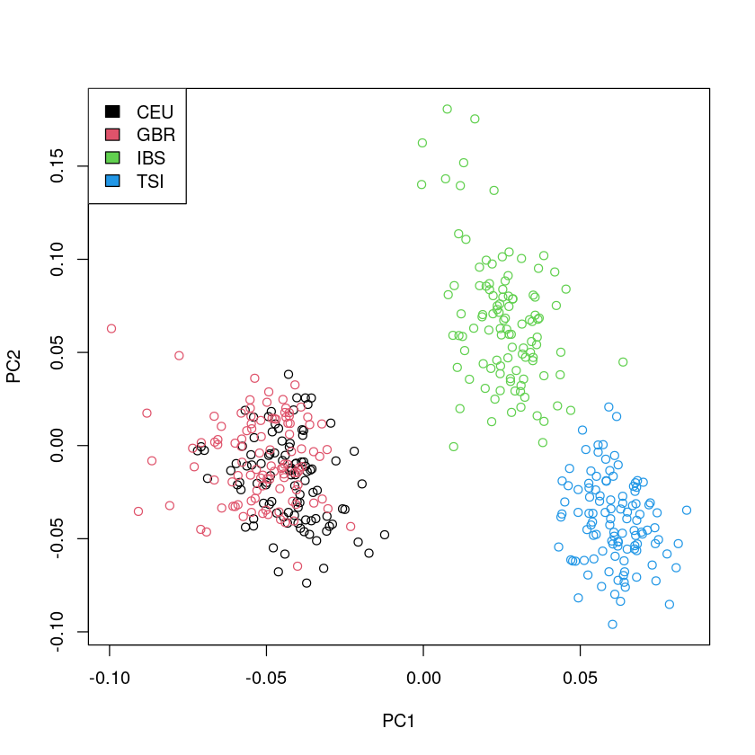

- Does the plot look like you expected? Which populations are close and distant to each other?

Since the European individuals in 1000G are not simple homogeneous disjoint populations it is hard to use PBS/FST or similar statistics to infer selection based on populating differences ( you will learn about these later). However, PCA offers a good description of the differences between individuals without having the define disjoint groups.

Let's try to infer selection along the genome based on the PCA

```
pcangsd -b ./pca/eu1000g.small.beagle.gz -o ./pca/EUsmall --selection -t 5 --sites-save
```

```
------------------------------------
PCAngsd v1.36.4
Jonas Meisner and Anders Albrechtsen
Using 5 thread(s)
------------------------------------

Parsing Beagle file.
Loaded 161428 sites and 424 samples.
Estimating minor allele frequencies.
EM (MAF) converged at iteration: 3
Number of sites after MAF filtering (0.05): 161154

Estimating covariance matrix.
Using 1 principal components (MAP test).
Individual allele frequencies estimated (1).
Individual allele frequencies estimated (2).	RMSE=0.0043007
Individual allele frequencies estimated (3).	RMSE=0.0018809
Individual allele frequencies estimated (4).	RMSE=0.0009596
Individual allele frequencies estimated (5).	RMSE=0.0005525
Individual allele frequencies estimated (6).	RMSE=0.0003512
Individual allele frequencies estimated (7).	RMSE=0.0002420
Individual allele frequencies estimated (8).	RMSE=0.0001776
Individual allele frequencies estimated (9).	RMSE=0.0001367
Individual allele frequencies estimated (10).	RMSE=0.0001090
Individual allele frequencies estimated (11).	RMSE=0.0000893
Individual allele frequencies estimated (12).	RMSE=0.0000746
Individual allele frequencies estimated (13).	RMSE=0.0000634
Individual allele frequencies estimated (14).	RMSE=0.0000545
Individual allele frequencies estimated (15).	RMSE=0.0000472
Individual allele frequencies estimated (16).	RMSE=0.0000413
Individual allele frequencies estimated (17).	RMSE=0.0000362
Individual allele frequencies estimated (18).	RMSE=0.0000320
Individual allele frequencies estimated (19).	RMSE=0.0000283
Individual allele frequencies estimated (20).	RMSE=0.0000251
Individual allele frequencies estimated (21).	RMSE=0.0000223
Individual allele frequencies estimated (22).	RMSE=0.0000198
Individual allele frequencies estimated (23).	RMSE=0.0000176
Individual allele frequencies estimated (24).	RMSE=0.0000157
Individual allele frequencies estimated (25).	RMSE=0.0000140
Individual allele frequencies estimated (26).	RMSE=0.0000125
Individual allele frequencies estimated (27).	RMSE=0.0000112
Individual allele frequencies estimated (28).	RMSE=0.0000100
PCAngsd converged.
Saved covariance matrix as ./pca/EUsmall.cov

Performing selection scan (FastPCA) for 1 PCs.
Saved test statistics as ./pca/EUsmall.selection

Creating boolean vector of sites surviving filters.
Saved boolean vector of sites kept after filtering as ./pca/EUsmall.sites
Total elapsed time: 0m45s
```

```
# Create file with position and chromosome
paste <(zcat ./pca/eu1000g.small.beagle.gz| cut -f 1 | sed 's/\_/\t/g' | sed 1d ) ./pca/EUsmall.sites  > ./pca/EUsmall.sites.info

head  ./pca/EUsmall.sites.info
```

```
chr1	787290	1
chr1	832873	1
chr1	855316	1
chr1	872843	1
chr1	893503	1
chr1	914838	1
chr1	931513	1
chr1	954724	1
chr1	975014	1
chr1	993036	1
```

Next, plot the results of the selection scan

```
s = scan("./pca/EUsmall.selection")

# convert test statistic to p-value
pval<-pchisq(s,1,lower=FALSE)

## make QQ plot to QC the test statistics
qqPlot(pval)
```

```
Read 161154 items
```

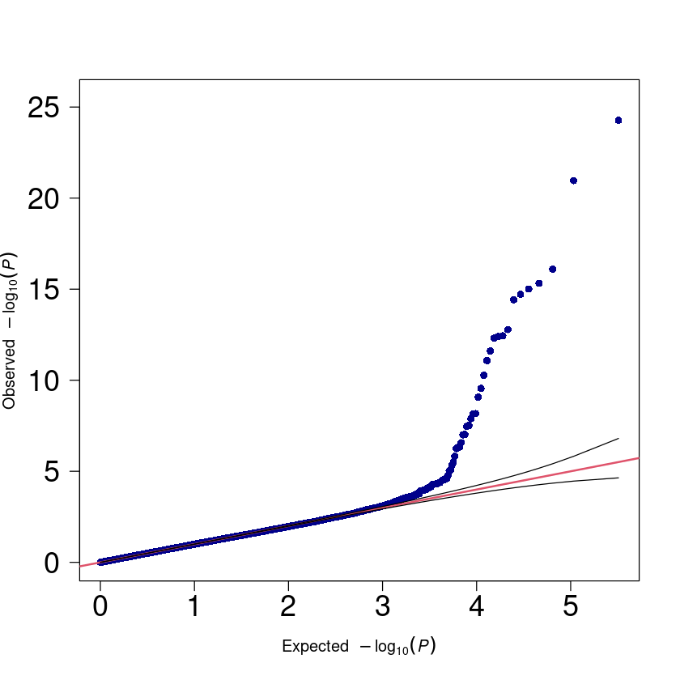

The above is a QQ plot of the p-values from the selection scan. If the test statistics is good them most point will follow the red line which only a few (<1%) will deviate.

- Did the test perform well?

Finally, let's plot the results of the scan along the genome:

```
## read positions (hg38)
data<-read.delim("./pca/EUsmall.sites.info",colC=c("factor","integer","integer"),head=F)
names(data)<-c("chr","pos","keep")
data <- subset(data,keep==1)
data$pval <- pval



## make manhatten plot
options(repr.plot.width = 10, repr.plot.height = 6)
manPlot(data$pval,chr=as.integer(data$chr))
```

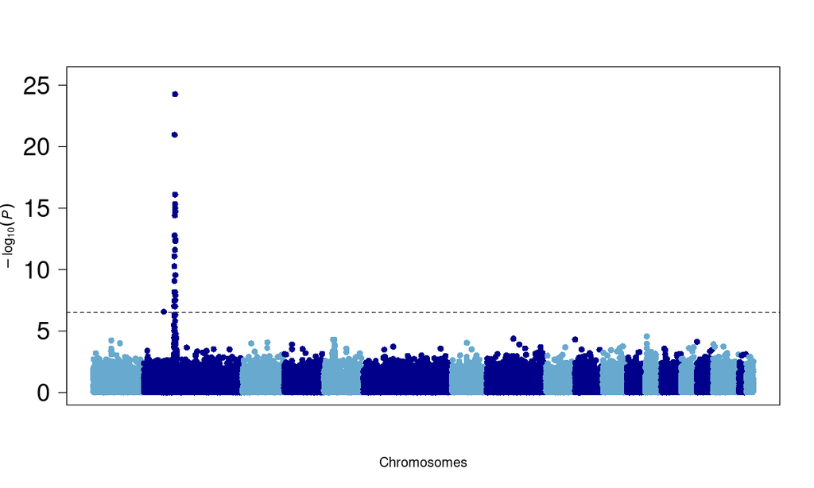

Lest zoom in

```
# select sites to plot, 0.5Mb on either side of SNP
leadSNPposition <- data$pos[which.max(s)]

region <- subset(data,chr=="chr2" & pos >  leadSNPposition - 5e5 &  pos < leadSNPposition + 5e5)


#plot
locusZoomNoLD(region$pval,chr=2,pos=region$pos,main="LocusZoom",build=38, geneticMap=geneticMap, refGenes=refGenes)
```

[figure not shown]

See if you can make sense of the top hit. What do you think it the relevant gene in that locus

# Bonus exercise

## Simple example of PCA and MDS

First let's try to perform PCA and MDS on the small matrix from the slides. The below code will input the genotypes into R.

```
#read in data from slides
G <-matrix(c(1,0,2,0,2,0,2,1,1,1,0,1,0,2,1,2,1,1,1,1,1,0,1,0,2,0,1,1,0,2,1,2,0,1,0),5,by=T,
           dimnames=list(paste0("IND",1:5),paste0("SNP",1:7)))
nInd <- nrow(G)

print(G)
```

```
     SNP1 SNP2 SNP3 SNP4 SNP5 SNP6 SNP7
IND1    1    0    2    0    2    0    2
IND2    1    1    1    0    1    0    2
IND3    1    2    1    1    1    1    1
IND4    0    1    0    2    0    1    1
IND5    0    2    1    2    0    1    0
```

```
## run the code to start a quiz
from jupyterquiz import display_quiz
display_quiz('pca_quiz1.json')
```

## MDS

Let's try to do MDS. First let's calculate the distance. The simple distance measure as seen in the slides is called a Manhattan distance.

```
## continue in R
D<-dist(G,upper=T,diag=T,method="manh")
D
```

```
     IND1 IND2 IND3 IND4 IND5
IND1    0    3    7   10   11
IND2    3    0    4    7    8
IND3    7    4    0    5    4
IND4   10    7    5    0    3
IND5   11    8    4    3    0
```

- How many dimensions are used to represent the distances?

Now let's reduce the number of dimension to 2 using MDS and plot the results:

```
k2<-cmdscale(D,k=2)

cat("\n Dimension reduction to two dimensions")
k2
cat("\n original Distance between individuals:")
org <- dist(G,upper=T,diag=T,method="manha")
org

cat("\n Distance between individuals in from the MDS:")
round(D_k2<- dist(k2,upper=T,diag=T),2)
```

```
 Dimension reduction to two dimensions
```

A matrix: 5 × 2 of type dbl

| IND1 | 6.114866 | 0.2977272 |
| --- | --- | --- |
| IND2 | 3.077094 | 0.2402932 |
| IND3 | -0.621230 | -1.7944048 |
| IND4 | -3.723118 | 2.1483083 |
| IND5 | -4.847612 | -0.8919238 |

```
 original Distance between individuals:
```

```
     IND1 IND2 IND3 IND4 IND5
IND1    0    3    7   10   11
IND2    3    0    4    7    8
IND3    7    4    0    5    4
IND4   10    7    5    0    3
IND5   11    8    4    3    0
```

```
 Distance between individuals in from the MDS:
```

```
      IND1  IND2  IND3  IND4  IND5
IND1  0.00  3.04  7.05 10.01 11.03
IND2  3.04  0.00  4.22  7.06  8.01
IND3  7.05  4.22  0.00  5.02  4.32
IND4 10.01  7.06  5.02  0.00  3.24
IND5 11.03  8.01  4.32  3.24  0.00
```

```
#plot the results
 plot(k2,pch=16,cex=3,col=1:5+1,ylab="distance 2th dimension",xlab="distance 1. dimension",main="Multiple dimension scaling (MDS)")
 points(k2,pch=as.character(1:5))
```

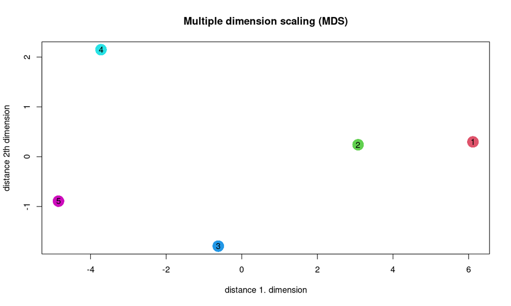

- Can you find any difference in the pairwise distances from the plot and the original pairwise distances?.

## PCA

First let's try to perform PCA directy on the normalized genotypes without calculating the covariance matrix

- Why do we normalize the genotypes?

```
#first normalize the data do that the mean and variance is the same for each SNP
normalize <- function(x){
    nInd <- nrow(x)
    avg <- colMeans(x)
    M <- x - rep(colMeans(x),each=nInd)
    M <- M/sqrt(2*rep(avg/2*(1-avg/2),each=nInd))
    M
 }
print(G)
 M <- normalize(G)
print(M)
cat("Dimension of M")
dim(M)

 svd <- svd(M)
 ## print the decomposition for M=SDV
 ## u is the eigenvectors
 ## d is eigen values
 print(svd)
```

```
     SNP1 SNP2 SNP3 SNP4 SNP5 SNP6 SNP7
IND1    1    0    2    0    2    0    2
IND2    1    1    1    0    1    0    2
IND3    1    2    1    1    1    1    1
IND4    0    1    0    2    0    1    1
IND5    0    2    1    2    0    1    0
           SNP1       SNP2      SNP3      SNP4       SNP5       SNP6       SNP7
IND1  0.6172134 -1.7320508  1.414214 -1.414214  1.7320508 -0.9258201  1.1547005
IND2  0.6172134 -0.2886751  0.000000 -1.414214  0.2886751 -0.9258201  1.1547005
IND3  0.6172134  1.1547005  0.000000  0.000000  0.2886751  0.6172134 -0.2886751
IND4 -0.9258201 -0.2886751 -1.414214  1.414214 -1.1547005  0.6172134 -0.2886751
IND5 -0.9258201  1.1547005  0.000000  1.414214 -1.1547005  0.6172134 -1.7320508
Dimension of M
```

1. 5

2. 7

```
$d
[1] 5.261803e+00 2.053667e+00 1.566501e+00 9.253336e-01 3.748163e-16

$u
            [,1]        [,2]       [,3]       [,4]      [,5]
[1,]  0.64933919  0.09424370 -0.5834128 -0.1706056 0.4472136
[2,]  0.35989402  0.07538164  0.5914222  0.5612608 0.4472136
[3,] -0.07799398 -0.60916998  0.3226848 -0.5645382 0.4472136
[4,] -0.39798601  0.72856890  0.1094660 -0.3143433 0.4472136
[5,] -0.53325321 -0.28902426 -0.4401602  0.4882264 0.4472136

$v
           [,1]       [,2]         [,3]       [,4]        [,5]
[1,]  0.2730876 -0.3302541  0.325740175 -0.2899575  0.35747149
[2,] -0.3457940 -0.6975136  0.429315165  0.1470835 -0.03356696
[3,]  0.2814894 -0.4368143 -0.625520546  0.2196783  0.50269419
[4,] -0.5215403  0.1858741 -0.305776626 -0.3312989  0.32151510
[5,]  0.4335716 -0.2426873 -0.232855131 -0.5373485 -0.52610467
[6,] -0.2959595 -0.1274489 -0.007889476 -0.6514342  0.16605338
[7,]  0.4231225  0.3223520  0.412944032 -0.1521959  0.45897074
```

The above is the decomposition of the genotypes into the diagonal matrix (d) with eigenvalues, and the left (u) and right (v) eigenvectors such that $M=U\Sigma V^T$ where $\Sigma$ has the diagonal values of d. Therefore, we can reconstruct the normalized genotypes from U, d and v:

```
##make a diagonal matrix with the eigenvalues
SIGMA <-  diag(svd$d)
print(SIGMA)
## using the matrixes from the decomposition we can undo the transformation of our normalized genotypes
M2 <- svd$u%*%SIGMA%*%t(svd$v)
cat("Original normalized genotypes (M):")
round(M,3)
cat("Reconstructed normalized genotypes(M2):")
round(M2,3)
```

```
         [,1]     [,2]     [,3]      [,4]         [,5]
[1,] 5.261803 0.000000 0.000000 0.0000000 0.000000e+00
[2,] 0.000000 2.053667 0.000000 0.0000000 0.000000e+00
[3,] 0.000000 0.000000 1.566501 0.0000000 0.000000e+00
[4,] 0.000000 0.000000 0.000000 0.9253336 0.000000e+00
[5,] 0.000000 0.000000 0.000000 0.0000000 3.748163e-16
Original normalized genotypes (M):
```

A matrix: 5 × 7 of type dbl

|  | SNP1 | SNP2 | SNP3 | SNP4 | SNP5 | SNP6 | SNP7 |
| --- | --- | --- | --- | --- | --- | --- | --- |
| IND1 | 0.617 | -1.732 | 1.414 | -1.414 | 1.732 | -0.926 | 1.155 |
| IND2 | 0.617 | -0.289 | 0.000 | -1.414 | 0.289 | -0.926 | 1.155 |
| IND3 | 0.617 | 1.155 | 0.000 | 0.000 | 0.289 | 0.617 | -0.289 |
| IND4 | -0.926 | -0.289 | -1.414 | 1.414 | -1.155 | 0.617 | -0.289 |
| IND5 | -0.926 | 1.155 | 0.000 | 1.414 | -1.155 | 0.617 | -1.732 |

```
Reconstructed normalized genotypes(M2):
```

A matrix: 5 × 7 of type dbl

| 0.617 | -1.732 | 1.414 | -1.414 | 1.732 | -0.926 | 1.155 |
| --- | --- | --- | --- | --- | --- | --- |
| 0.617 | -0.289 | 0.000 | -1.414 | 0.289 | -0.926 | 1.155 |
| 0.617 | 1.155 | 0.000 | 0.000 | 0.289 | 0.617 | -0.289 |
| -0.926 | -0.289 | -1.414 | 1.414 | -1.155 | 0.617 | -0.289 |
| -0.926 | 1.155 | 0.000 | 1.414 | -1.155 | 0.617 | -1.732 |

- Did the reconstruction of the normalized genotypes work?
- Would you be able to reconstruct the unnormalized (raw) genotypes?

Now try performing PCA based on the covariance matrix instead. To do so we first calculate the covariance matrix:

```
## calculate the covariance matrix
C <- M %*% t(M)
 print(C)
```

```
          IND1       IND2       IND3       IND4      IND5
IND1 12.571429  5.5714286 -2.0238095 -6.9761905 -9.142857
IND2  5.571429  4.7380952 -0.7738095 -3.7261905 -5.809524
IND3 -2.023810 -0.7738095  2.2619048 -0.7738095  1.309524
IND4 -6.976190 -3.7261905 -0.7738095  6.7380952  4.738095
IND5 -9.142857 -5.8095238  1.3095238  4.7380952  8.904762
```

The covariance matrix also shows the relationship between each individuals with the most similar individuals having a high positive value while the most distant individuals having a negativ value. However, unlike the euclidian distance the diagonal is not zero but instead is it related to the diversity within each individual.

Now let's try to do PCA on this covariance matrix instead

```
## then perform the PCA by singular value decomposition
 e <- eigen(C)

 ## print first PC
cat("First pricipal component:")
 print(e$vectors[,1])
 ## print first PC
cat("Eigenvalues:")
 print(round(e$values,4))
 ##plot 2 first PC. for the 5 indiviudals
 plot(e$vectors[,1:2],pch=16,cex=3,col=1:5+1,ylab="2. PC",xlab="1. PC",main="Principle component analysis (PCA)")
 points(e$vectors[,1:2],pch=as.character(1:5))
```

```
First pricipal component:[1] -0.64933919 -0.35989402  0.07799398  0.39798601  0.53325321
Eigenvalues:[1] 27.6866  4.2175  2.4539  0.8562  0.0000
```

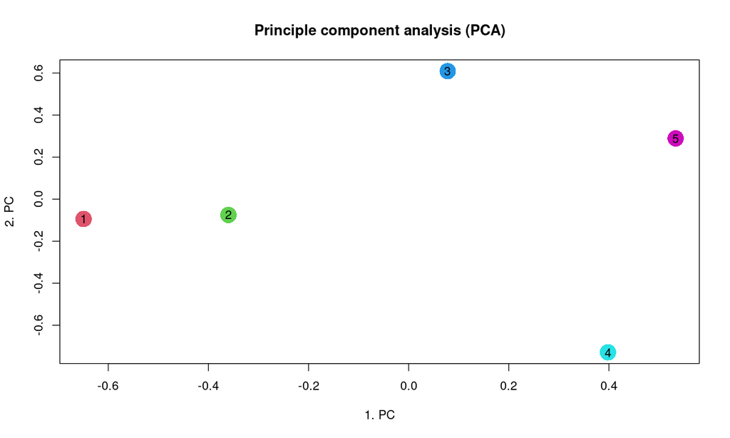

- Do you get the same results using the covariance matrix as using the normalized genotypes directly?
- Compare the two plots (MDS vs. PCA). Are the capturing the same thing?

Bonus information:

Unlike MDS, PCA will not remove information, so you are actually able to reconstruct your covariance matrix from the principal components.

```
##continue in R
##make a diagonal matrix with the eigenvalues
SIGMA <- diag(e$value)

## transform the PC back to the original data
## using matrix multiplication V SIGMA Vt
out <- e$vectors %*% SIGMA %*% t(e$vectors)
cat("Reconstructed covariance:")
print(out)
cat("Original covariance:")
print(C)
#close R after you are done
```

```
Reconstructed covariance:          [,1]       [,2]       [,3]       [,4]      [,5]
[1,] 12.571429  5.5714286 -2.0238095 -6.9761905 -9.142857
[2,]  5.571429  4.7380952 -0.7738095 -3.7261905 -5.809524
[3,] -2.023810 -0.7738095  2.2619048 -0.7738095  1.309524
[4,] -6.976190 -3.7261905 -0.7738095  6.7380952  4.738095
[5,] -9.142857 -5.8095238  1.3095238  4.7380952  8.904762
Original covariance:          IND1       IND2       IND3       IND4      IND5
IND1 12.571429  5.5714286 -2.0238095 -6.9761905 -9.142857
IND2  5.571429  4.7380952 -0.7738095 -3.7261905 -5.809524
IND3 -2.023810 -0.7738095  2.2619048 -0.7738095  1.309524
IND4 -6.976190 -3.7261905 -0.7738095  6.7380952  4.738095
IND5 -9.142857 -5.8095238  1.3095238  4.7380952  8.904762
```

Try to also compare the eigenvalues from the decomposition of the normalized genotypes and from the covariance matrix

```
cat("Eigenvalues of the covariance matrix:")
 print(round(e$values,4))

cat("Singular values from the normalized genotypes:")
 print(round(svd$d,4))
```

```
Eigenvalues of the covariance matrix:[1] 27.6866  4.2175  2.4539  0.8562  0.0000
Singular values from the normalized genotypes:[1] 5.2618 2.0537 1.5665 0.9253 0.0000
```

- What is the relationship? (hint: try to square one of them by changing the above code)